# Problem Set 02

Week 02 Day 01

# Learning objectives

- Construct confidence intervals - of varying levels - for means and proportions
- Distinguish between correct and incorrect interpretations of confidence intervals
- Articulate the role sample size and confidence level play in a confidence interval
- Identify connections between research questions and parameters of interest

# Exercises

## By hand or typed

### Exericse 1

[HTZ 7.3-13] Based on telephone interviews in October 2017 of a random sample of 1028 adults, Gallup News Service reported that 617 favored stricter gun control laws. Interviews of 1041 adults in March 2018 showed that 694 favored stricter gun control laws. Let $p_1$ and $p_2$ be the respective proportions in 2017 and 2018 who favored stricter gun control laws.

1. Find point estimates of $p_1$ and $p_2$
2. Find an approximate 95% confidence interval for $p_1 - p_2$

### Exericse 2

[HTZ 7.1-2] A random sample of size 8 from $N(\mu, 72)$ yielded $\overline{X} = 85$. Find the following confidence intervals for $\mu$:

1. 99%
2. 95%
3. 90%
4. 80%

### Exericse 3

[HTZ 7.1-16] Let $\overline{X}$ be the mean of a random sample of size $n$ from $N(\mu, 9)$. Find $n$ such that $P(\overline{X} - 1 < \mu < \overline{X} + 1) = 0.9$

## Typed

### Exericse 4

Suppose that a region has two hospitals. Hospital A has about 10 births per day, and hospital B has about 50 births per day. About 50% of all babies are boys, but the percentage who are boys varies at each hospital from day to day. Over the course of a year, which hospital will have more days on which 60% or more of the births are boys – A, B, or negligible difference between A and B?

### Exericse 5

Suppose we want to estimate the average runtime of a feature film in the documentary genre. I selected a simple random sample of 50 documentary films from the population of 3472 documentaries listed at IMDb ([here](http://www.imdb.com/)).

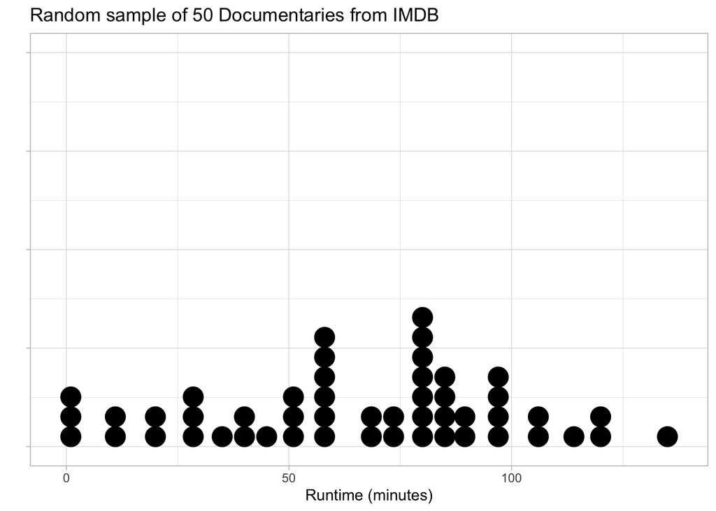

```
## # A tibble: 7 × 2
##   names       x
##   <chr>   <dbl>
## 1 Min.      1
## 2 1st Qu.  41.2
## 3 Median   71
## 4 Mean     65.4
## 5 3rd Qu.  87
## 6 Max.    135
## 7 StDev    33.5
```

1. What are the observational units and variable? What type of variable is this?
2. Describe the relevant population and parameter. Also indicate an appropriate symbol for this parameter.
3. Identify the appropriate confidence interval procedure.
4. Are the technical conditions for this procedure satisfied? Explain.
5. Calculate a 95% confidence interval for the population mean.
6. Interpret this interval.
7. Approximately what percentage of the films in the sample have times that fall within this interval?
8. Is this percentage close to 95%? Should it be? Explain what went wrong, or explain that nothing went wrong.

### Exericse 6

Consider the population of thriller movies from the IMDB database, and assume we computed a 95% CI for average runtime to be [94.5, 108.9]. Identify which of the following statements are *correct* interpretations of the confidence interval. For incorrect interpretations, explain *why* they are incorrect.

1. We are 95% confident that a thriller film in the IMDb list runs for between 94.5 and 108.9 minutes.
2. There’s a 95% chance that a thriller film in the IMDb list runs for between 94.5 and 108.9 minutes.
3. We are 95% confident that the population mean is between 94.5 and 108.9 minutes.
4. We are 95% confident that the population mean runtime of a thriller film in the IMDb list is between 94.5 and 108.9 minutes.
5. About 95% of all thriller films in the IMDb list run for between 94.5 and 108.9 minutes.
6. We are 95% confident that the mean runlength of a thriller film in this sample from the IMDb list was between 94.5 and 108.9 minutes.
7. We are 95% confident that the mean runlength of a thriller film in a new random sample from the IMDb list would be between 94.5 and 108.9 minutes.
8. We are 95% confident that the population mean runtime of a thriller film in the IMDb list is between 94.5 and 108.9 minutes.
9. There’s a 95% chance (or a 0.95 probability) that the population mean runlength of a thriller film in the IMDb list is between 94.5 and 108.9 minutes.

### Exericse 7

Birthweights of babies in the U.S. can be modeled by a normal distribution with mean 3300 grams and standard deviation 500 grams. Consider selecting a random sample of 400 newborns from this population. Which is larger: the probability that a single randomly selected newborn weighs between 3200 and 3400 grams, or the probability that the sample mean birthweight in the random sample of 400 newborns is between 3200 and 3400 grams? Explain your answer.

### Exericse 8

State a research question where a confidence interval for each of the following parameters would be of interest:

1. one mean
2. one proportion
3. a difference in proportions

## BONUS / Stretch Exercise

Choose the Theorem from 2.5 (that $T \sim t_{(n-1)}$) or the Theorem from 5.2 (CI for two proportions) and type up an annotated proof (using LaTeX in RMarkdown).

## Submission

Once you have completed all Exercises and written up your results in the Template .Rmd provided, take about 5-10 minutes to respond to the reflection prompts (RP) at the top of the Template:

- (RP1): *What were the main concepts covered in this assignment?*
- (RP2): *What’s one thing you understand better after completing these problems?*
- (RP3): *What problems gave you the most trouble? What was difficult about them/where did you get stuck?*

Knit your document one final time, then upload your .html file to Problem Set 02 on Canvas.

## Grading (50pts)

| Component | Points |
| --- | --- |
| RP1 | 5 |
| RP2 | 5 |
| RP3 | 5 |
| Formatting & Clarity | 5 |
| Exercise completion | 30 |